# yelp文集-類別比較文字雲

鄭竹秀、黃天原

首先先設置Spark的設定

```r
library(dplyr)
library(sparklyr)
Sys.setenv(SPARK_HOME="/usr/local/spark/spark-2.4.5-bin-hadoop2.7")
config <- spark_config()
config$spark.executor.memory = "32G"
config$spark.driver.memory = "32G"
config$spark.cores.max = "96"
config$spark.yarn.executor.memoryOverhead = "4096"
sc <- spark_connect(master = "spark://hnamenode:7077", config = config)
```

```
Re-using existing Spark connection to spark://hnamenode:7077
```

### 一、篩選掉非英文詞彙

```r
tEN = spark_read_parquet(sc, "ten", "/home/sum2020/yelp14/pq/token_en")
```

```r
tEN %>% summarise_at(vars(doc_id,token), n_distinct)
```

| doc_id | token |
| --- | --- |
| 7983243 | 1199897 |

首先將待處裡的資料，從Spark的路徑讀入。目前的詞頻表中，有7983243篇獨立評論，與1199897個不重複的詞彙。

```r
terms = tEN %>% group_by(token) %>% summarise(
  t_freq = sum(freq),
  a_tfidf = mean(tfidf),
  n_docs = n()
  )
A = collect(terms)

library(stringr)
D = A %>% filter(
  str_detect(token, "^[A-Za-z]{2,}$"),
  t_freq >= 30, n_docs >=10, a_tfidf <= 1,
  )
D = subset(D, a_tfidf > median(a_tfidf))

# save(A, D, file='Terms.rdata')
```

[output not shown]

```r
spark_write_parquet(dtmEN, "/home/sum2020/yelp14/pq/dtmEN")
spark_disconnect(sc)
```

將資料寫出後，斷開Spark連結。此時可以重新啟動R

### 二、比較泰國與越南餐廳較常出現的詞彙

在這部份，本文將選擇標籤為「泰國餐廳」與「越南餐廳」的商家，選出於這些商家的評論，比較在這兩種餐廳的評論中，出現的詞彙有何差異。

#### 1. 找出類別是這兩種餐廳的商家評論id

```r
### choose two restaurants ----

# load
pacman::p_load(stringr, dplyr, wordcloud)

load("data/Bmx.RData")
load("data/rev_id.RData")
rev <- rev_biz_id
rm(rev_biz_id)
# gc()
```

找出我們要比較的商店類別，分別是`"Thai"`跟`"Vietnamese"`

```r
# find Thai and Vietnamese restaurants rid
str_subset(colnames(Bmx), "Thai")
```

```
[1] "Thai"      "Muay Thai"
```

```r
str_subset(colnames(Bmx), "Viet")
```

```
[1] "Vietnamese"
```

先找出標籤是越南餐廳跟泰國餐廳的店家的id，像是`-8R_-EkGpUhBk55K9Dd4mg`

```r
thai <- rownames(Bmx)[Bmx[, "Restaurants"] & Bmx[, "Thai"]]
viet <- rownames(Bmx)[Bmx[, "Restaurants"] & Bmx[, "Vietnamese"]]
cat('Thai restaurant: ', length(thai),'\n')
```

```
Thai restaurant:  1547
```

```r
cat('Vietnamese restaurant: ', length(viet), '\n')
```

```
Vietnamese restaurant:  1409
```

```r
intersect(thai, viet) %>% length() %>% cat('intersect stores: ', ., '\n')
```

```
intersect stores:  234
```

泰國餐廳有`1547`間，越南餐廳有`1409`間，重疊的商家數是`234`

接著使用這些商家的`business_id`，將這些店家的評論文章的id `rev`選出來。

```r
rev <- filter(rev, business_id %in% union(thai, viet))
rev$thai <- rev$business_id %in% thai
rev$viet <- rev$business_id %in% viet
rev$year <- lubridate::year(rev$date)
rev$rid <- as.character(rev$rid)
```

完成之後，以`TRUE` `FALSE`向量標注該店家是泰國或越南餐廳，再加入評論的年份。

#### 2. 利用評論id選出詞彙

找出評論id`rev`後，我們下一步一樣要利用Spark的運算效能，將剛剛還剩5924848篇獨立評論、47402個獨立詞彙的詞頻表`dtmEN`中，選出我們要的token

```r
### load spark ----
# source('/home/b056090027/sparkLink.R') #sc
library(sparklyr)
Sys.setenv(SPARK_HOME="/usr/local/spark/spark-2.4.5-bin-hadoop2.7")
config <- spark_config()
config$spark.executor.memory = "32G"
config$spark.driver.memory = "32G"
config$spark.cores.max = "96"
config$spark.yarn.executor.memoryOverhead = "4096"
sc <- spark_connect(master = "spark://hnamenode:7077", config = config)
```

[output not shown]

查看目前`dtmEN`的資料型態

```r
# do filter
rid = as.character(rev$rid)
head(dtmEN)
```

| doc_id | token | freq | n_tokens | tf | n_docs | idf | tfidf |
| --- | --- | --- | --- | --- | --- | --- | --- |
| 1924928 | AEY | 1 | 163 | 0.006134969 | 30 | 12.49639 | 0.07666498 |
| 3109616 | AEY | 1 | 88 | 0.011363636 | 30 | 12.49639 | 0.14200445 |
| 643872 | AEY | 1 | 74 | 0.013513514 | 30 | 12.49639 | 0.16887016 |
| 6257316 | AEY | 1 | 239 | 0.004184100 | 30 | 12.49639 | 0.05228616 |
| 5660012 | AEY | 3 | 167 | 0.017964072 | 30 | 12.49639 | 0.22448607 |
| 3392996 | AEY | 1 | 151 | 0.006622517 | 30 | 12.49639 | 0.08275756 |

```r
token_rest = dtmEN %>%
  filter(doc_id %in% rid)
```

```r
token_rest %>% summarise_at(vars(doc_id,token), n_distinct)
```

| doc_id | token |
| --- | --- |
| 189362 | 21770 |

經過用評論id`rev`選取後，剩下189362篇獨立評論，以及21770個詞彙，這是我們準備畫對照文字雲的資料

將資料以parquet格式，寫出至hadoop

```r
spark_write_parquet(token_rest, "/home/sum2020/yelp14/pq/rest")
```

將資料`collect`回本機記憶體，然後斷開`Spark`，儲存`RData`。

```r
rest = collect(token_rest)
spark_disconnect(sc)
save(rest, file = 'data/restaurant.RData')
```

```r
### draw the wc
# clean data
pacman::p_load(stringr, dplyr, wordcloud)

# Ice Cream & Frozen Yogurt vs Juice Bars & Smoothies
# y := weighted average of year
#   y在下方最後的結果是`yr`，算法是算出token在每年的比例，再乘上年份
#   換句話說就是年份的加權平均，越大代表近年討論較多

# x := freq1/(freq1+freq2)
#   x就是freq

# size = sum(下面用`sum`表示)
# hist(x); hist(y)); hist(size);

load(file = "data/restaurant.RData")
head(rest)
```

| doc_id | token | freq | n_tokens | tf | n_docs | idf | tfidf |
| --- | --- | --- | --- | --- | --- | --- | --- |
| 2089947 | AUCE | 2 | 31 | 0.064516129 | 59 | 11.820051 | 0.76258396 |
| 572518 | AUCE | 1 | 174 | 0.005747126 | 59 | 11.820051 | 0.06793133 |
| 5931941 | AUCE | 1 | 68 | 0.014705882 | 59 | 11.820051 | 0.17382429 |
| 2946317 | Ahwatukee | 1 | 76 | 0.013157895 | 3555 | 7.721479 | 0.10159840 |
| 7894189 | Ahwatukee | 1 | 163 | 0.006134969 | 3555 | 7.721479 | 0.04737103 |
| 1399552 | Ahwatukee | 1 | 32 | 0.031250000 | 3555 | 7.721479 | 0.24129620 |

查看完資料型態後，我們下一步要做的，是計算出每個獨立的token，欲畫在x軸與y軸上的數值。

- x軸: 使用詞彙在其中一間餐廳被提及的詞頻，佔總詞頻的比例。 即`freq1 / (freq1 + freq2)`
- y軸: 年份的加權平均，藉此觀察該詞彙是較近期的流行詞，或是較以前的流行詞。

```r
token_sum <- rest %>%
  select(-(n_tokens:tfidf)) %>%
  left_join(select(rev, -business_id), by = c("doc_id" = "rid")) %>%
  count(token, name = "sum")

token_wt <- rest %>%
  select(-(n_tokens:tfidf)) %>%
  left_join(select(rev, -business_id), by = c("doc_id" = "rid")) %>%
  left_join(token_sum) %>%
  group_by(token, year) %>%
  summarise(n = n(), sum = first(sum), wt = n / sum) %>%
  ungroup()

token_wt <- token_wt %>%
  mutate(yr_wt = year * wt) %>%
  group_by(token) %>%
  summarise(yr = sum(yr_wt))
# 這邊是算出個token的年份加權，也就是拿來畫圖的y
```

首先先算出每個token的年份加權平均

```r
Y_thai <- rest %>%
  filter(doc_id %in% rev$rid[rev$thai]) %>%
  group_by(token) %>%
  summarise(thai_freq = sum(freq))

Y_viet <- rest %>%
  filter(doc_id %in% rev$rid[rev$viet]) %>%
  group_by(token) %>%
  summarise(viet_freq = sum(freq))
# 這兩個是要計算token在泰國跟越南餐廳各自提到的次數

Y <- token_wt %>%
  left_join(Y_thai) %>%
  left_join(Y_viet) %>%
  as.data.frame()

Y[is.na(Y)] <- 0
Y$freq <- Y$thai_freq / (Y$thai_freq + Y$viet_freq)
Y <- left_join(Y, token_sum)
```

接著算出該詞彙各自在泰國餐廳與越南餐廳出現的次數，最後在算出泰國餐廳的出現次數，佔總次數的佔比，也就是`Y$freq`，數字接近1，代表在泰國餐廳的頻論較容易提及，接近0則是越南餐廳；0.5則代表在兩種餐廳出現的頻率很接近。

接著查看x軸與y軸的分佈

```r
# choose the amount of words
arrange(Y, desc(freq))
```

| token | yr | thai_freq | viet_freq | freq | sum |
| --- | --- | --- | --- | --- | --- |
| Aaaah | 2014.000 | 1 | 0 | 1 | 1 |
| aaaand | 2016.167 | 6 | 0 | 1 | 6 |
| aamco | 2015.000 | 1 | 0 | 1 | 1 |
| Aamco | 2012.500 | 2 | 0 | 1 | 2 |
| AAMCO | 2014.500 | 2 | 0 | 1 | 2 |
| aand | 2013.000 | 2 | 0 | 1 | 2 |
| Ab | 2014.000 | 1 | 0 | 1 | 1 |
| abacus | 2018.000 | 1 | 0 | 1 | 1 |
| Abacus | 2015.333 | 3 | 0 | 1 | 3 |
| Abandoned | 2016.000 | 1 | 0 | 1 | 1 |

[output cut: 990 more lines]

```r
summary(Y)
```

```
    token                 yr         thai_freq
 Length:21770       Min.   :2006   Min.   :    0.00
 Class :character   1st Qu.:2014   1st Qu.:    1.00
 Mode  :character   Median :2015   Median :    2.00
                    Mean   :2015   Mean   :   14.06
                    3rd Qu.:2016   3rd Qu.:    4.00
                    Max.   :2019   Max.   :30842.00
   viet_freq             freq             sum
 Min.   :    0.00   Min.   :0.0000   Min.   :    1.00
 1st Qu.:    0.00   1st Qu.:0.3333   1st Qu.:    1.00
 Median :    1.00   Median :0.6364   Median :    2.00
 Mean   :   14.85   Mean   :0.5948   Mean   :   21.35
 3rd Qu.:    3.00   3rd Qu.:1.0000   3rd Qu.:    7.00
 Max.   :73852.00   Max.   :1.0000   Max.   :39618.00
```

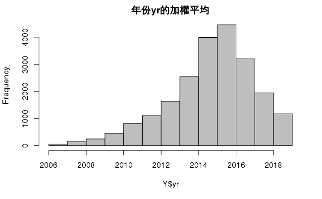

這邊可以看到，在這兩種餐廳的評論中，大部分的評論還是集中在2014~2016年

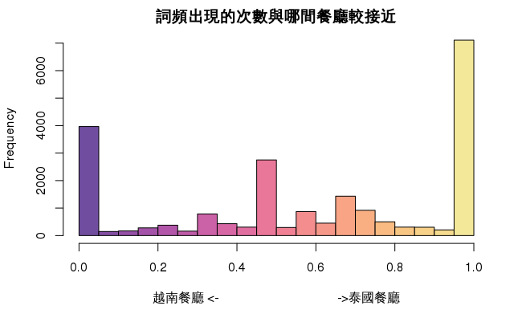

而大部分的詞彙，都是特別偏向0或1，代表較集中在其中一種餐廳。如果是較為泛用的詞彙，則較集中在0.5左右，在後面的字雲圖，也可以觀察到這個趨勢。

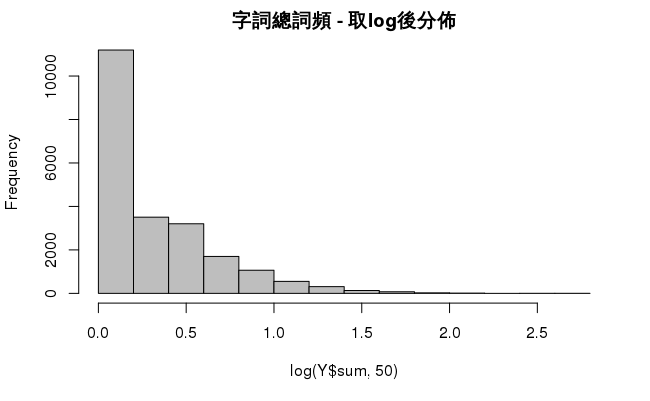

而每個詞彙的總詞頻分佈，即使取過log之後，依舊可以看到有相當多的詞彙，只出現過很少的次數，

|  | token | sum |
| --- | --- | --- |
| 14393 | pho | 39618 |
| 14394 | Pho | 25623 |
| 19062 | thai | 21063 |
| 12158 | mi | 5462 |
| 1352 | banh | 4294 |
| 4985 | Delicious | 3826 |
| 6351 | Excellent | 3807 |
| 525 | Amazing | 3322 |
| 13962 | panang | 3216 |
| 13963 | Panang | 3208 |

[output cut: 990 more lines]

```r
# 先選個100個詞瞧瞧
Y_wc <- Y %>%
  arrange(desc(sum)) %>%
  slice(6:100)
head(Y_wc)
```

|  | token | yr | thai_freq | viet_freq | freq | sum |
| --- | --- | --- | --- | --- | --- | --- |
| 1 | Delicious | 2015.909 | 2617 | 1506 | 0.6347320 | 3826 |
| 2 | Excellent | 2015.846 | 2779 | 1373 | 0.6693160 | 3807 |
| 3 | Amazing | 2016.331 | 2445 | 1181 | 0.6742967 | 3322 |
| 4 | panang | 2015.230 | 3904 | 119 | 0.9704201 | 3216 |
| 5 | Panang | 2015.175 | 3740 | 165 | 0.9577465 | 3208 |
| 6 | ew | 2015.953 | 3587 | 109 | 0.9705087 | 3028 |

由於文字雲不能呈現太多詞彙，而詞頻最高的幾個詞，可能會是無意義的文字。所以我們選擇前一百多的文字，去掉前五個。

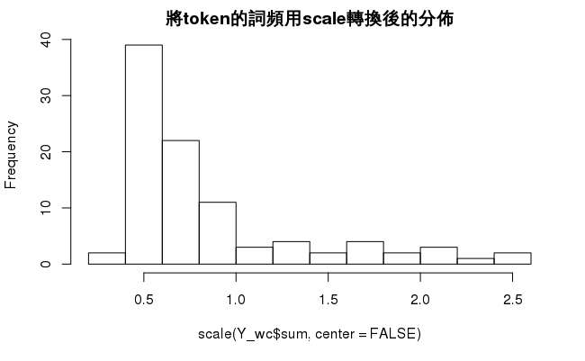

```r
hist(scale(Y_wc$sum, center = FALSE), main = "將token的詞頻用scale轉換後的分佈")
```

經過`scale()`轉換後，詞彙的總詞頻落在0~2.5之間，這樣後面文字雲呈現的詞頻多寡，會較容易閱讀。

```r
# render plot
textplot(
  Y_wc$freq,
  Y_wc$yr,
  Y_wc$token,
  cex = scale(Y_wc$sum, center = FALSE),
  show.lines = FALSE
)
```

終於要畫文字雲了！下面除了越南與泰國餐廳之外，也做了 Ice Cream & Frozen Yogurt 跟 Juice Bars & Smoothies這兩個類別的比較。因為從資料處理到畫文字雲的過程差不多，所以就直接呈現結果了

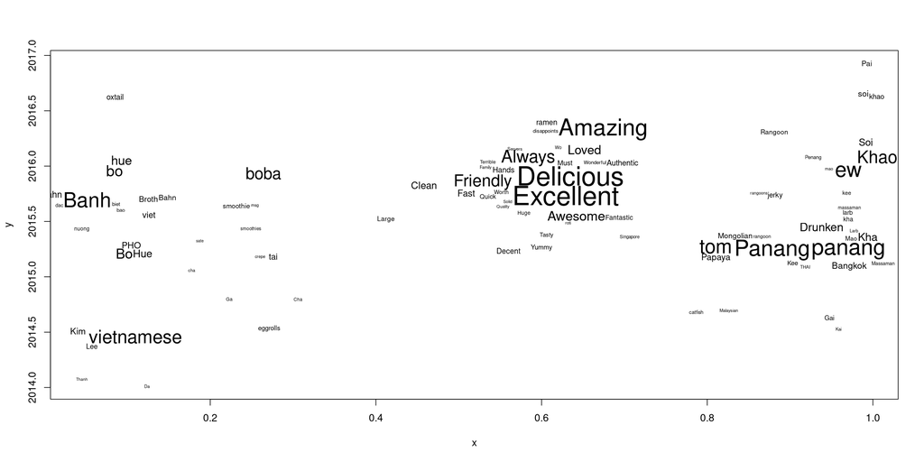

畫出來的主要分成三個區域，橫軸數字越偏向0代表字詞出現在越南餐廳頻率越高，數字越偏向1代表字詞出現在泰國餐廳的頻率越高，中間區域表示中性的詞彙。

先從中間看起，Amazing、Delicious、Excellent等詞彙出現次數眾多，在越南與泰國餐廳中出現頻率也差不多。

再來是偏向數字1的區域，大部分出現的字詞都是泰國的食物，例如Panang（紅咖哩）、khao soi（泰北麵）、Tom kha（南薑椰汁湯），比較有趣的是這裡出現papaya，卻沒有泰國著名的山竹、榴蓮等，不過應該表示他們著名的涼拌青木瓜。除了食物，還有關於泰式按摩的Massaman、jerky（抽筋的）。

再來是偏向數字0的區域，大部分出現的字詞都是越南的食物，broth（肉湯）、oxtail（牛尾）、eggroll（蛋捲/餅)，還有smoothie、boba等甜食，與泰國比起來又更多元一點，並且也有少數的msg按摩文化。不過美食的部分泰國的種類更多一點，許多著名的菜色都有被列出來討論。

## save the image

```r
png("wc.png", width = 2400, height = 1200, res = 160)
textplot(
  Y_wc$freq,
  Y_wc$yr,
  Y_wc$token,
  cex = scale(Y_wc$sum, center = FALSE),
  show.lines = FALSE
)
dev.off()
```

# Ice Cream & Frozen Yogurt vs. Juice Bars & Smoothies

[figure not shown]

從縱軸來看，可以看到整體字詞的集中趨勢位於圖片上半部的區域。從原始資料分布來看，在2016年後的留言數量較多，表示因為這些字詞在2016年後出現的頻率較高，因此大多集中在這個區段間。

比較特別的是在右方的字詞分佈相當平均，越偏向橫軸1的字詞在Ice Cream & Frozen Yogurt這個商業類別出現的頻率較高，也可以看出在2014年到2018年間，使用者留言的內容有較多的差異，能夠看出不同時期的趨勢，像是較早在2014年的Yogurtland（冷凍酸奶公司）特別被討論。

再來是DQ(Diary Queen，是一間連鎖霜淇淋和速食餐廳）推出的Blizzard霜淇淋與capcake，在2016年討論聲量高，其次是Baskin-Robbins（美國連鎖冰淇淋店）。

而近年來聲量比較高的詞彙以Matcha（抹茶）為大宗，推測可能是抹茶口味的冰淇淋、優格比較受歡迎。

從橫軸來看，中間區塊分佈較中性的詞彙，像是：Delicious、Amazing、Friendly、Awesome等，在Ice Cream & Frozen Yogurt 和 Juice Bars & Smoothies兩個商業類別中都蠻常出現的。

偏向1的表示在Ice Cream & Frozen Yogurt 類別的評論文集中較常被使用，而比較多像是foryo（霜凍優格)、gelato（義式冰淇淋）或是描述口味的flavors等詞彙。

偏向0的是在Juice Bars & Smoothies 類別的評論文集中較常被使用，在此商業類別中，有的店家也被分類至nighttime、restaurant，因此裡面會出現vibes、poke等詞彙；也會有不同國家的料理，如：Greek、Dutch或者是Vegan、bagel、donuts、latte、barista（咖啡師）、Boba（波霸奶茶）等不同形式的料理。比較有聲量的商店名稱是Burgatory與Jamba。 而對於注重健康的族群，討論度越來越高，因此都集中在2016年後，像是Healthy、Acai（巴西莓果)、Vegan等。